# Baseline Nowcast Evaluation: Flu NSSP

#### Per-nowcast

Per-nowcast-date aggregated across geos, showing how performance evolved over the evaluation period. The ribbon is the IQR across geos; the black line is the mean, the blue line the median. Below that is a plot of the percentage increase from the as_of to the final_value, with similar definitions.

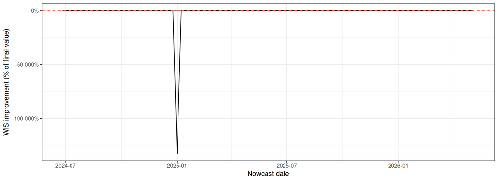

```r
h1_scores |>
  group_by(nowcast_date) |>
  summarise(
    mean_pct = mean(pct_improvement),
    q25 = quantile(pct_improvement, 0.25),
    median_pct = quantile(pct_improvement, 0.5),
    q75 = quantile(pct_improvement, 0.75),
    n = n(),
    .groups = "drop"
  ) |>
  ggplot(aes(nowcast_date)) +
  geom_line(aes(y = median_pct), alpha = 0.5, fill = "blue") +
  geom_ribbon(aes(ymin = q25, ymax = q75), alpha = 0.2, fill = "steelblue") +
  geom_line(aes(y = mean_pct)) +
  geom_hline(yintercept = 0, linetype = "dashed", colour = "tomato") +
  scale_y_continuous(labels = scales::percent) +
  labs(x = "Nowcast date", y = "WIS improvement (% of final value)")
```

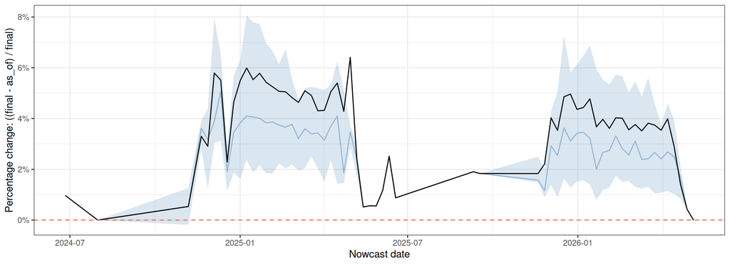

```r
h1_scores |>
  group_by(nowcast_date) |>
  summarise(
    mean_bias = mean(as_of_bias, na.rm = TRUE),
    q25 = quantile(as_of_bias, 0.25, na.rm = TRUE),
    median_bias = quantile(as_of_bias, 0.5, na.rm = TRUE),
    q75 = quantile(as_of_bias, 0.75, na.rm = TRUE),
    .groups = "drop"
  ) |>
  ggplot(aes(nowcast_date)) +
  geom_ribbon(aes(ymin = q25, ymax = q75), alpha = 0.2, fill = "steelblue") +
  geom_line(aes(y = median_bias), alpha = 0.5, colour = "steelblue") +
  geom_line(aes(y = mean_bias)) +
  geom_hline(yintercept = 0, linetype = "dashed", colour = "tomato") +
  scale_y_continuous(labels = scales::percent) +
  labs(x = "Nowcast date", y = "Percentage change: ((final - as_of) / final)")
```

Somewhat surprisingly, 10 weeks is more than enough time to learn the process, and very roughly the earlier data is somewhat more proficient. That somewhat correlates with a period of higher percentage increase, but like in the case of states this is not very strong.

#### Decreases present in revision triangle

This is a simple bar graph to detect whether the presence of downward revisions is associated with systematically different performance.

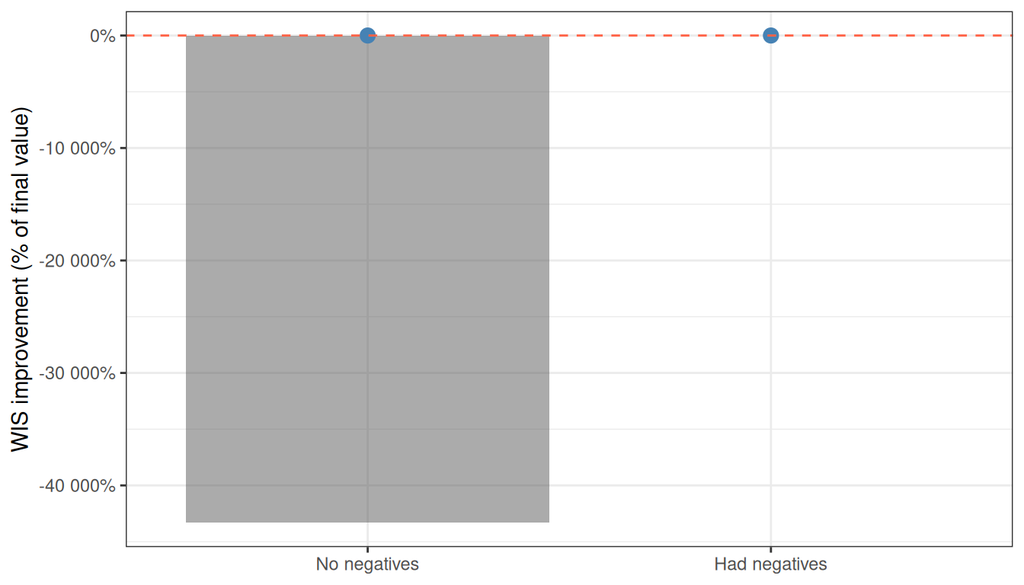

```r
h1_scores |>
  group_by(has_negatives) |>
  summarise(
    mean_pct = mean(pct_improvement),
    median_pct = median(pct_improvement),
    q25 = quantile(pct_improvement, 0.25),
    q75 = quantile(pct_improvement, 0.75),
    n = n(),
    .groups = "drop"
  ) |>
  ggplot(aes(has_negatives)) +
  geom_col(aes(y = mean_pct), alpha = 0.5) +
  geom_pointrange(aes(y = median_pct, ymin = q25, ymax = q75),
                  colour = "steelblue", size = 0.6) +
  geom_hline(yintercept = 0, linetype = "dashed", colour = "tomato") +
  scale_y_continuous(labels = scales::percent) +
  scale_x_discrete(labels = c("FALSE" = "No negatives", "TRUE" = "Had negatives")) +
  labs(x = NULL, y = "WIS improvement (% of final value)")
```

## Coverage

Empirical coverage of 50% and 90% credible intervals.

```r
retro_nowcasts |>
  left_join(final_values_retro, by = join_by(geo_value, reference_date)) |>
  filter(!is.na(final_value)) |>
  summarise(
    `50% coverage` = mean(final_value >= q25 & final_value <= q75),
    `90% coverage` = mean(final_value >= q05 & final_value <= q95),
    n = n()
  )
```

```
# A tibble: 1 × 3
  `50% coverage` `90% coverage`     n
           <dbl>          <dbl> <int>
1          0.280          0.451 26329
```

## Nowcasts for most-revised weeks

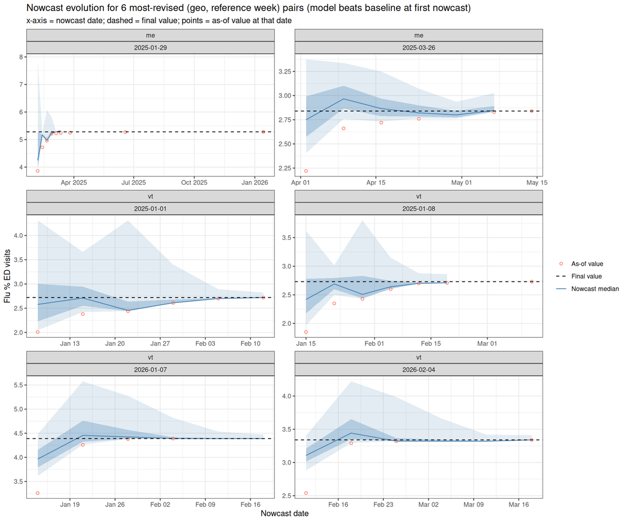

```r
top_revised <- revision_sum$revision_behavior |>
  filter(
    geo_value %nin% c("vi", "as", "gu"),
    min_value > 1,
    n_revisions > 1,
  ) |>
  inner_join(
    h1_scores |> filter(pct_improvement > 0) |> select(geo_value, reference_date, pct_improvement),
    by = join_by(geo_value, time_value == reference_date)
  ) |>
  slice_max(pct_improvement, n = 6) |>
  select(geo_value, reference_date = time_value)

high_rev_as_of <- nssp_archive$DT |>
  rename(reference_date = time_value, nowcast_date = version, as_of_value = value) |>
  semi_join(top_revised, by = join_by(geo_value, reference_date)) |>
  select(geo_value, nowcast_date, reference_date, as_of_value)

high_rev_summary <- retro_nowcasts |>
  inner_join(top_revised, by = join_by(geo_value, reference_date)) |>
  left_join(final_values_retro, by = join_by(geo_value, reference_date))

ggplot(high_rev_summary, aes(nowcast_date)) +
  geom_ribbon(aes(ymin = q05, ymax = q95), alpha = 0.15, fill = "steelblue") +
  geom_ribbon(aes(ymin = q25, ymax = q75), alpha = 0.3, fill = "steelblue") +
  geom_line(aes(y = median, colour = "Nowcast median")) +
  geom_point(
    data = high_rev_as_of,
    aes(x = nowcast_date, y = as_of_value, colour = "As-of value"),
    shape = 1, size = 1.5
  ) +
  geom_hline(aes(yintercept = final_value, colour = "Final value"), linetype = "dashed") +
  scale_colour_manual(values = c(
    "Nowcast median" = "steelblue",
    "As-of value" = "tomato",
    "Final value" = "black"
  )) +
  facet_wrap(~ geo_value + reference_date, scales = "free", ncol = 2) +
  labs(
    title = "Nowcast evolution for 6 most-revised (geo, reference week) pairs (model beats baseline at first nowcast)",
    subtitle = "x-axis = nowcast date; dashed = final value; points = as-of value at that date",
    x = "Nowcast date", y = "Flu % ED visits", colour = NULL
  )
```

Funnily enough, as the `nowcast_date` pulls further into the future relative to the `reference_date`, the nowcast narrows on the as_of value pretty drastically. This may explain some of the issues that the nowcaster has with larger horizons. Thankfully most days don’t actually need very many nowcasts (the ones plotted above are somewhat exceptional).

## Nowcast vs final over time

Plotting the latest nowcast for each nowcast_date; this will be the day which has the worst quality data, and the one we’re most interested in getting right.

The other option would be to choose the last nowcast that is ever made for any given day, which may actually be asking what we nowcast months later.

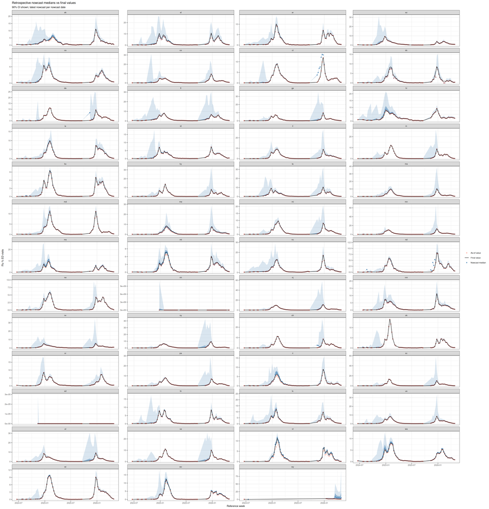

```r
as_of_retro <- retro_nowcasts$nowcast_date |>
  unique() |>
  purrr::map(\(d) nssp_archive |> epix_as_of(d) |> mutate(nowcast_date = d)) |>
  list_rbind() |>
  rename(reference_date = time_value, as_of_value = value) |>
  select(geo_value, nowcast_date, reference_date, as_of_value)

retro_summary <- retro_nowcasts |>
  group_by(geo_value, nowcast_date) |>
  slice_max(reference_date, n = 1) |>
  ungroup() |>
  left_join(final_values_retro, by = join_by(geo_value, reference_date)) |>
  left_join(as_of_retro, by = join_by(geo_value, nowcast_date, reference_date))
plot_ex <- retro_summary |> filter(geo_value %nin% c("vi", "as", "gu")) |> pull(geo_value) |> unique()
ggplot(retro_summary |> filter(geo_value %in% plot_ex), aes(reference_date)) +
  geom_ribbon(aes(ymin = q25, ymax = q75),
              alpha = 0.5, fill = "steelblue") +
  geom_ribbon(aes(ymin = q05, ymax = q95),
              alpha = 0.2, fill = "steelblue") +
  geom_point(aes(y = median, colour = "Nowcast median"), size = 1) +
  geom_point(aes(y = as_of_value, colour = "As-of value"), shape = 1, size = 1) +
  geom_line(
    data = semi_join(final_values_retro, retro_summary, by = join_by(geo_value, reference_date)) |> filter(geo_value %in% plot_ex),
    aes(y = final_value, colour = "Final value")
  ) +
  facet_wrap(~ geo_value, scales = "free_y", ncol=4) +
  scale_colour_manual(values = c(
    "Nowcast median" = "steelblue",
    "As-of value" = "tomato",
    "Final value" = "black"
  )) +
  theme(text = element_text(size = 9), plot.title = element_text(size = 11)) +
  labs(
    title = "Retrospective nowcast medians vs final values",
    subtitle = "90% CI shown; latest nowcast per nowcast date",
    x = "Reference week", y = "Flu % ED visits", colour = NULL
  )
```

since the 95% being as large as it is obscures the values, here’s a capped version to get a clearer plot.

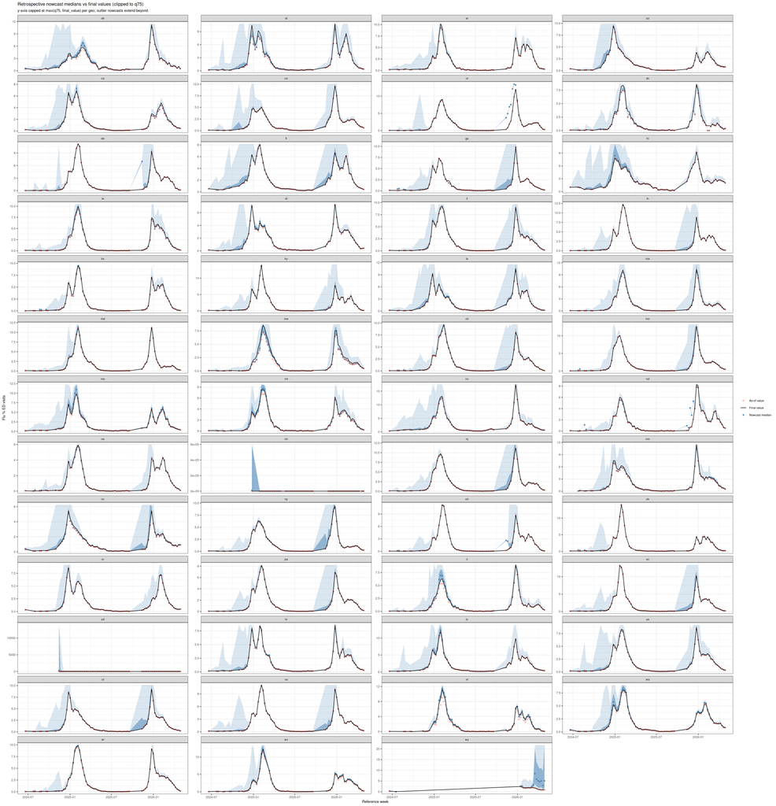

```r
retro_clipped <- retro_summary |>
  filter(geo_value %in% plot_ex) |>
  group_by(geo_value) |>
  mutate(y_max = max(q75, final_value, na.rm = TRUE)) |>
  ungroup() |>
  mutate(across(c(q05, q25, median, q75, q95, as_of_value), \(x) pmin(x, y_max)))

ggplot(retro_clipped, aes(reference_date)) +
  geom_ribbon(aes(ymin = q25, ymax = q75),
              alpha = 0.5, fill = "steelblue") +
  geom_ribbon(aes(ymin = q05, ymax = q95),
              alpha = 0.2, fill = "steelblue") +
  geom_point(aes(y = median, colour = "Nowcast median"), size = 1) +
  geom_point(aes(y = as_of_value, colour = "As-of value"), shape = 1, size = 1) +
  geom_line(
    data = semi_join(final_values_retro, retro_clipped, by = join_by(geo_value, reference_date)),
    aes(y = final_value, colour = "Final value")
  ) +
  facet_wrap(~ geo_value, scales = "free_y", ncol=4) +
  scale_colour_manual(values = c(
    "Nowcast median" = "steelblue",
    "As-of value" = "tomato",
    "Final value" = "black"
  )) +
  theme(text = element_text(size = 9), plot.title = element_text(size = 11)) +
  labs(
    title = "Retrospective nowcast medians vs final values (clipped to q75)",
    subtitle = "y-axis capped at max(q75, final_value) per geo; outlier nowcasts extend beyond",
    x = "Reference week", y = "Flu % ED visits", colour = NULL
  )
```

# Retrospective Evaluation (Population-Weighted)

Same pipeline applied to `value * state_population / 100` — an estimate of the absolute number of ED visits rather than the percentage. This is closer to count data and so should be a better fit for the reporting-triangle model.

```r
geo_values_popwt <- unique(nssp_archive_popwt$DT$geo_value)

retro_grid_popwt <- tidyr::expand_grid(
  nowcast_date = retro_nowcast_dates,
  geo = geo_values_popwt
)

plan(multisession, workers = parallel::detectCores() - 1)
retro_nowcasts_popwt <- furrr::future_pmap(
  retro_grid_popwt,
  run_retro_nowcast,
  incremental_data = incremental_data_popwt,
  .options = furrr_options(seed = TRUE)
) |>
  purrr::compact() |>
  bind_rows()
plan(sequential)

cat("Total nowcast dates to evaluate:", nrow(retro_nowcasts_popwt), "\n")
```

```
Total nowcast dates to evaluate: 26329
```

```r
cat("Reference dates covered:", n_distinct(retro_nowcasts_popwt$reference_date), "\n")
```

```
Reference dates covered: 101
```

```r
final_values_retro_popwt <- nssp_archive_popwt |>
  epix_as_of_current() |>
  select(geo_value, reference_date = time_value, final_value = value)

calc_naive_wis_popwt <- function(as_of_date) {
  nssp_archive_popwt |>
    epix_as_of(as_of_date) |>
    rename(reference_date = time_value, as_of_value = value) |>
    left_join(final_values_retro_popwt, by = join_by(geo_value, reference_date)) |>
    mutate(nowcast_date = as_of_date, naive_wis = abs(as_of_value - final_value)) |>
    select(geo_value, nowcast_date, reference_date, as_of_value, naive_wis)
}
naive_wis_popwt <- map(retro_nowcasts_popwt$nowcast_date |> unique(), calc_naive_wis_popwt) |>
  list_rbind()

scores_popwt <- retro_nowcasts_popwt |>
  left_join(final_values_retro_popwt, by = join_by(geo_value, reference_date)) |>
  filter(!is.na(final_value)) |>
  pivot_longer(
    cols = c(q05, q25, median, q75, q95),
    names_to = "quantile_level",
    values_to = "predicted"
  ) |>
  mutate(
    quantile_level = case_match(
      quantile_level,
      "q05" ~ 0.05, "q25" ~ 0.25, "median" ~ 0.5, "q75" ~ 0.75, "q95" ~ 0.95
    ),
    model = "baselinenowcast"
  ) |>
  rename(observed = final_value) |>
  as_forecast_quantile(
    forecast_unit = c("model", "nowcast_date", "reference_date", "geo_value"),
    observed = "observed",
    predicted = "predicted",
    quantile_level = "quantile_level"
  ) |>
  score() |>
  left_join(naive_wis_popwt, by = join_by(geo_value, nowcast_date, reference_date)) |>
  filter(!is.na(naive_wis)) |>
  mutate(
    relative_wis = wis / naive_wis,
    horizon_weeks = difftime(nowcast_date, reference_date, units = "weeks")
  )

scores_popwt |>
  summarise(
    skill = round(1 - mean(wis) / mean(naive_wis), 3),
    mean_wis = round(mean(wis), 2),
    mean_naive_wis = round(mean(naive_wis), 2),
    across(c(overprediction, underprediction, dispersion), ~ round(mean(.x), 2))
  )
```

```
    skill mean_wis mean_naive_wis overprediction underprediction dispersion
1 -80.352 276388.3        3397.45        5175.72         1105.93   270106.6
```

```r
cat(sprintf(
  "Nowcast beats naive: %d of %d scored instances (%.1f%%)\n",
  sum(scores_popwt$wis < scores_popwt$naive_wis),
  nrow(scores_popwt),
  100 * mean(scores_popwt$wis < scores_popwt$naive_wis)
))
```

```
Nowcast beats naive: 7049 of 26317 scored instances (26.8%)
```

## Horizon-1 diagnostics (population-weighted)

```r
negatives_flag_popwt <- retro_nowcasts_popwt |>
  distinct(geo_value, nowcast_date, has_negatives)

h1_scores_popwt <- scores_popwt |>
  filter(round(as.numeric(horizon_weeks)) == 1) |>
  filter(geo_value %nin% c("vi", "as", "gu")) |>
  left_join(final_values_retro_popwt, by = join_by(geo_value, reference_date)) |>
  left_join(negatives_flag_popwt, by = join_by(geo_value, nowcast_date)) |>
  filter(final_value > 100) |>
  mutate(
    pct_improvement = (naive_wis - wis) / final_value,
    as_of_bias = (final_value - as_of_value) / final_value,
    month = lubridate::month(reference_date, label = TRUE, abbr = TRUE),
    archive_weeks = as.numeric(difftime(
      nowcast_date, min(nssp_archive_popwt$DT$time_value), units = "weeks"
    )),
    group = if_else(
      pct_improvement >= median(pct_improvement), "helps (top half)", "hurts (bottom half)"
    )
  )
```

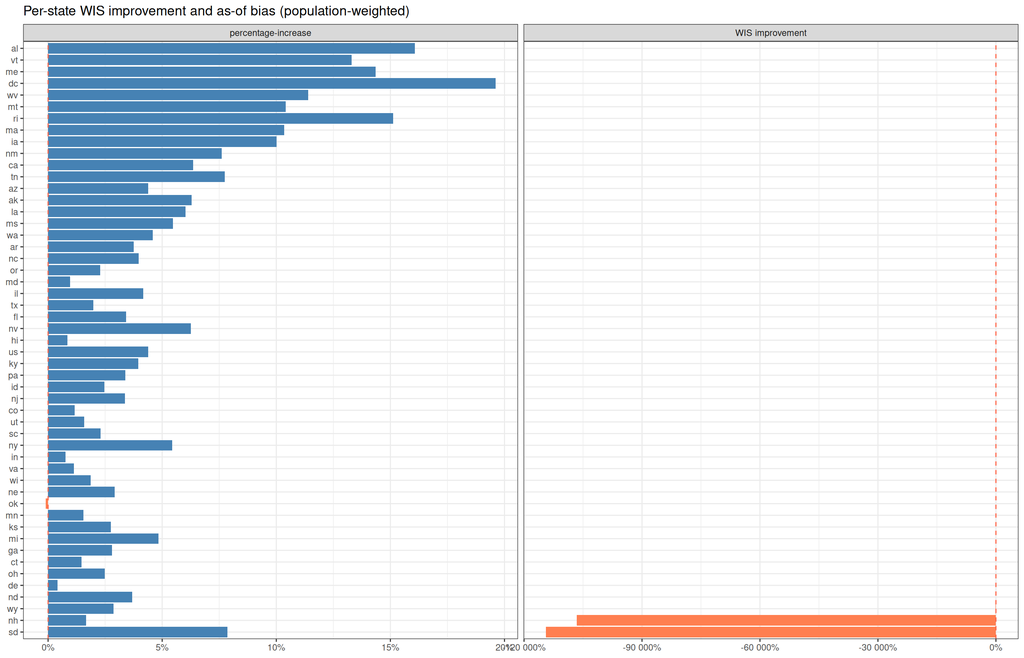

```r
h1_scores_popwt |>
  group_by(geo_value) |>
  summarise(
    `WIS improvement` = mean(pct_improvement),
    `percentage-increase` = mean(as_of_bias, na.rm = TRUE),
    .groups = "drop"
  ) |>
  mutate(geo_value = forcats::fct_reorder(geo_value, `WIS improvement`)) |>
  pivot_longer(c(`WIS improvement`, `percentage-increase`), names_to = "metric", values_to = "value") |>
  mutate(metric = factor(metric, levels = c("percentage-increase", "WIS improvement"))) |>
  ggplot(aes(value, geo_value, fill = value > 0)) +
  geom_col() +
  geom_vline(xintercept = 0, linetype = "dashed", colour = "tomato") +
  scale_x_continuous(labels = scales::percent) +
  scale_fill_manual(values = c("TRUE" = "steelblue", "FALSE" = "coral"), guide = "none") +
  facet_grid(~ metric, scales = "free_x") +
  labs(x = NULL, y = NULL, title = "Per-state WIS improvement and as-of bias (population-weighted)")
```

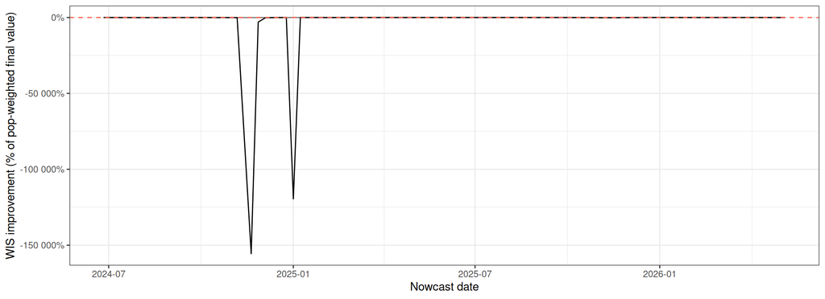

```r
h1_scores_popwt |>
  group_by(nowcast_date) |>
  summarise(
    mean_pct = mean(pct_improvement),
    q25 = quantile(pct_improvement, 0.25),
    median_pct = quantile(pct_improvement, 0.5),
    q75 = quantile(pct_improvement, 0.75),
    .groups = "drop"
  ) |>
  ggplot(aes(nowcast_date)) +
  geom_line(aes(y = median_pct), alpha = 0.5, fill = "blue") +
  geom_ribbon(aes(ymin = q25, ymax = q75), alpha = 0.2, fill = "steelblue") +
  geom_line(aes(y = mean_pct)) +
  geom_hline(yintercept = 0, linetype = "dashed", colour = "tomato") +
  scale_y_continuous(labels = scales::percent) +
  labs(x = "Nowcast date", y = "WIS improvement (% of pop-weighted final value)")
```

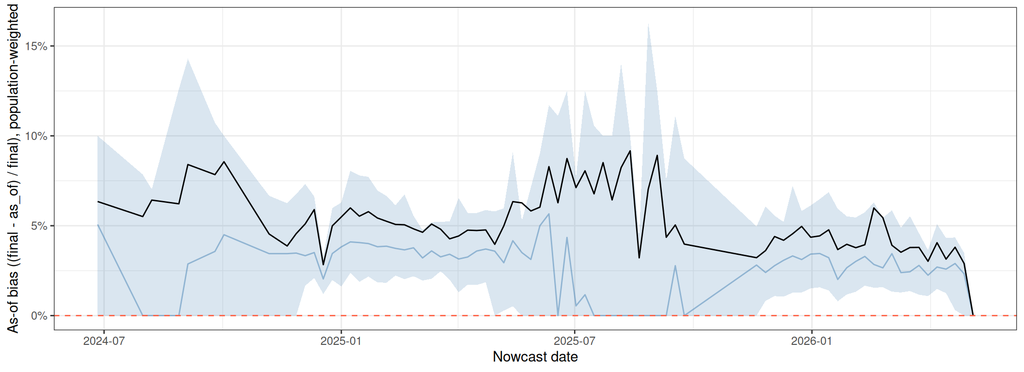

```r
h1_scores_popwt |>
  group_by(nowcast_date) |>
  summarise(
    mean_bias = mean(as_of_bias, na.rm = TRUE),
    q25 = quantile(as_of_bias, 0.25, na.rm = TRUE),
    median_bias = quantile(as_of_bias, 0.5, na.rm = TRUE),
    q75 = quantile(as_of_bias, 0.75, na.rm = TRUE),
    .groups = "drop"
  ) |>
  ggplot(aes(nowcast_date)) +
  geom_ribbon(aes(ymin = q25, ymax = q75), alpha = 0.2, fill = "steelblue") +
  geom_line(aes(y = median_bias), alpha = 0.5, colour = "steelblue") +
  geom_line(aes(y = mean_bias)) +
  geom_hline(yintercept = 0, linetype = "dashed", colour = "tomato") +
  scale_y_continuous(labels = scales::percent) +
  labs(x = "Nowcast date", y = "As-of bias ((final - as_of) / final), population-weighted")
```

## Nowcast vs final over time (population-weighted)

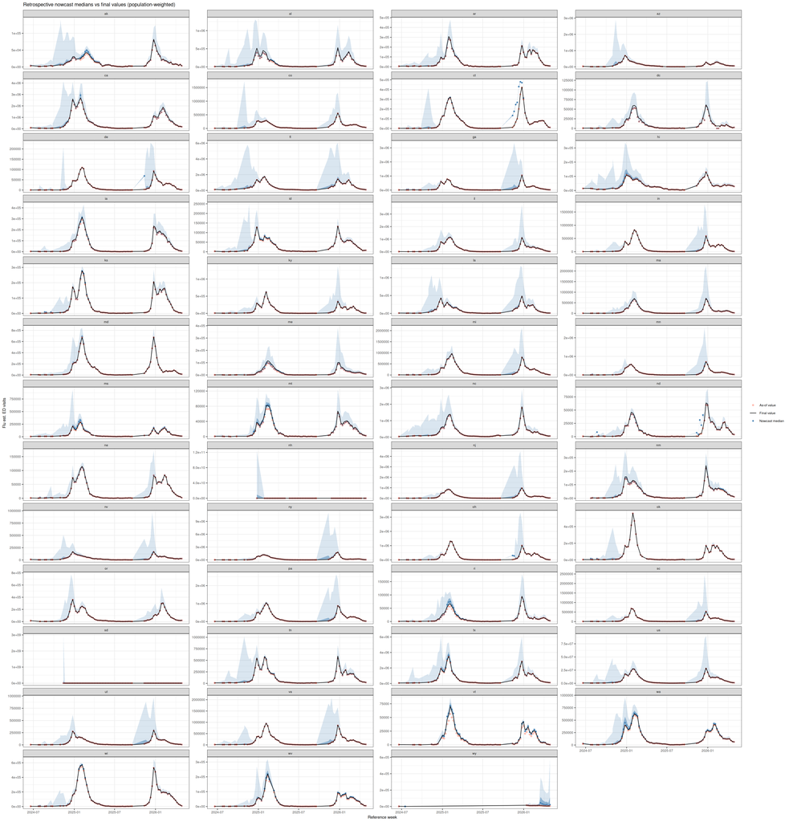

```r
as_of_retro_popwt <- retro_nowcasts_popwt$nowcast_date |>
  unique() |>
  purrr::map(\(d) nssp_archive_popwt |> epix_as_of(d) |> mutate(nowcast_date = d)) |>
  list_rbind() |>
  rename(reference_date = time_value, as_of_value = value) |>
  select(geo_value, nowcast_date, reference_date, as_of_value)

retro_summary_popwt <- retro_nowcasts_popwt |>
  group_by(geo_value, nowcast_date) |>
  slice_max(reference_date, n = 1) |>
  ungroup() |>
  left_join(final_values_retro_popwt, by = join_by(geo_value, reference_date)) |>
  left_join(as_of_retro_popwt, by = join_by(geo_value, nowcast_date, reference_date))

plot_ex_popwt <- retro_summary_popwt |>
  filter(geo_value %nin% c("vi", "as", "gu")) |>
  pull(geo_value) |>
  unique()

ggplot(retro_summary_popwt |> filter(geo_value %in% plot_ex_popwt), aes(reference_date)) +
  geom_ribbon(aes(ymin = q25, ymax = q75), alpha = 0.5, fill = "steelblue") +
  geom_ribbon(aes(ymin = q05, ymax = q95), alpha = 0.2, fill = "steelblue") +
  geom_point(aes(y = median, colour = "Nowcast median"), size = 1) +
  geom_point(aes(y = as_of_value, colour = "As-of value"), shape = 1, size = 1) +
  geom_line(
    data = semi_join(final_values_retro_popwt, retro_summary_popwt, by = join_by(geo_value, reference_date)) |>
      filter(geo_value %in% plot_ex_popwt),
    aes(y = final_value, colour = "Final value")
  ) +
  facet_wrap(~ geo_value, scales = "free_y", ncol = 4) +
  scale_colour_manual(values = c(
    "Nowcast median" = "steelblue",
    "As-of value" = "tomato",
    "Final value" = "black"
  )) +
  theme(text = element_text(size = 9), plot.title = element_text(size = 11)) +
  labs(
    title = "Retrospective nowcast medians vs final values (population-weighted)",
    x = "Reference week", y = "Flu est. ED visits", colour = NULL
  )
```

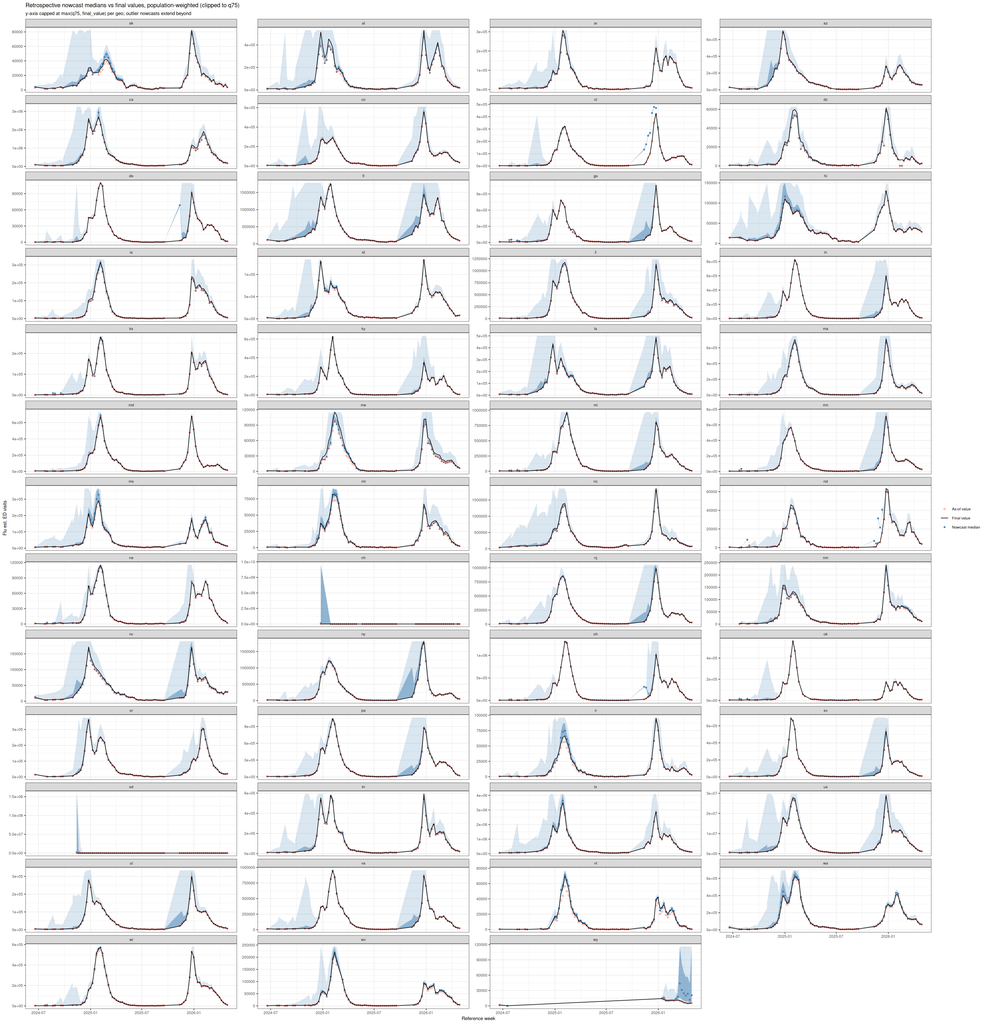

```r
retro_clipped_popwt <- retro_summary_popwt |>
  filter(geo_value %in% plot_ex_popwt) |>
  group_by(geo_value) |>
  mutate(y_max = max(q75, final_value, na.rm = TRUE)) |>
  ungroup() |>
  mutate(across(c(q05, q25, median, q75, q95, as_of_value), \(x) pmin(x, y_max)))

ggplot(retro_clipped_popwt, aes(reference_date)) +
  geom_ribbon(aes(ymin = q25, ymax = q75), alpha = 0.5, fill = "steelblue") +
  geom_ribbon(aes(ymin = q05, ymax = q95), alpha = 0.2, fill = "steelblue") +
  geom_point(aes(y = median, colour = "Nowcast median"), size = 1) +
  geom_point(aes(y = as_of_value, colour = "As-of value"), shape = 1, size = 1) +
  geom_line(
    data = semi_join(final_values_retro_popwt, retro_clipped_popwt, by = join_by(geo_value, reference_date)),
    aes(y = final_value, colour = "Final value")
  ) +
  facet_wrap(~ geo_value, scales = "free_y", ncol = 4) +
  scale_colour_manual(values = c(
    "Nowcast median" = "steelblue",
    "As-of value" = "tomato",
    "Final value" = "black"
  )) +
  theme(text = element_text(size = 9), plot.title = element_text(size = 11)) +
  labs(
    title = "Retrospective nowcast medians vs final values, population-weighted (clipped to q75)",
    subtitle = "y-axis capped at max(q75, final_value) per geo; outlier nowcasts extend beyond",
    x = "Reference week", y = "Flu est. ED visits", colour = NULL
  )
```